# Proposed Changes

**Corporate Sustainability Reporting Directive(CSRD):** Recent proposed amendments to the CSRD aim to narrow the scope of the directive by concentrating reporting obligations on larger undertakings. This adjustment is intended to alleviate the administrative burden on Small and Medium-sized Enterprises (SMEs), ensuring that sustainability reporting remains impactful without disproportionately affecting smaller businesses. It is estimated the 80% entities currently in scope of the directive will be exempted.

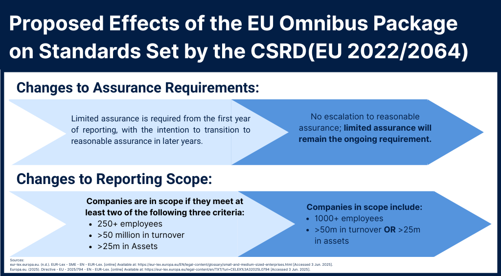

**Corporate Sustainability Due Diligence Directive(CSDDD):** Proposals to change the CSDDD do not include changes in scope but rather removing the required reporting from indirect suppliers unless there is a clear indication of harm. This change aims to shield SMEs from what information can be required from suppliers and value chains.

**Carbon Border Adjustment Mechanism(CBAM):** The proposed changes to CBAM largely work to lessen the financial and administrative burden of CBAM certification requirements on importers. The proposal if adopted, would exempt 90% of importers included in CBAM, while covering 99% of total emissions.

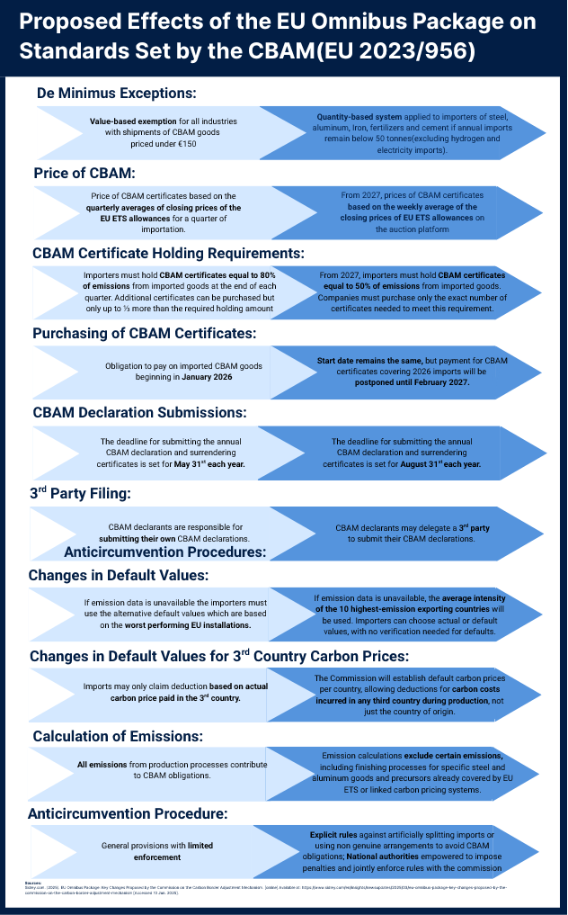

**EU Taxonomy:** The proposed changes to the EU Taxonomy aim to reduce administrative burdens. Under current legislation, all companies within the CSRD scope are automatically subject to Taxonomy requirements, including full compliance with technical screening criteria. The proposal narrows the scope to the largest companies under CSDDD, introduces partial compliance, and allows CSRD companies below CSDDD thresholds to voluntarily opt-in for reporting.